# Contextualizando as eleições

Nathan Giachetta

28 de agosto de 2017

Este documento tem como objetivo contextualizar as eleições da Terceira República em busca de perguntas que possam fomentar as discussões da matéria.

# Algumas análises

## Quantidade de eleitores aptos para votar durante as eleições para deputados federais da Terceira República

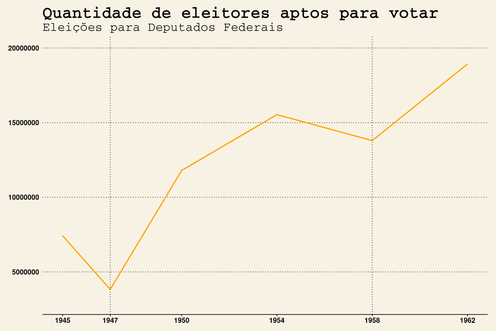

Vemos que a quantidade de eleitores aptos cresceu ao longo do período, porém os anos de 1947 e 1958 mostram quedas relacionadas aos anos anteriores. Uma pergunta possível seria encontrar quais os motivos para a diminuição de eleitores aptos.

## Quantidade de comparecimentos nas eleições para deputados federais da Terceira República

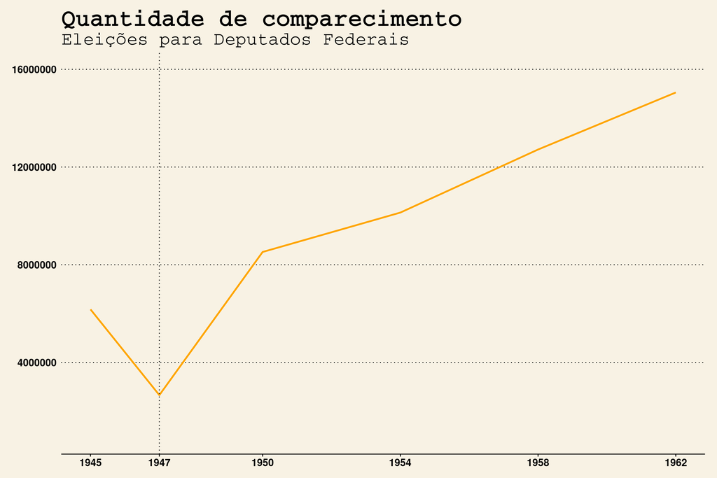

Assim como no gráfico anterior, temos uma tendência de crescimento, porém em 1947 temos uma queda em relação a 1945, como explicar este movimento?

## Quantidade de votos recebidos para Deputado Federal (PSD, UDN, PTB)

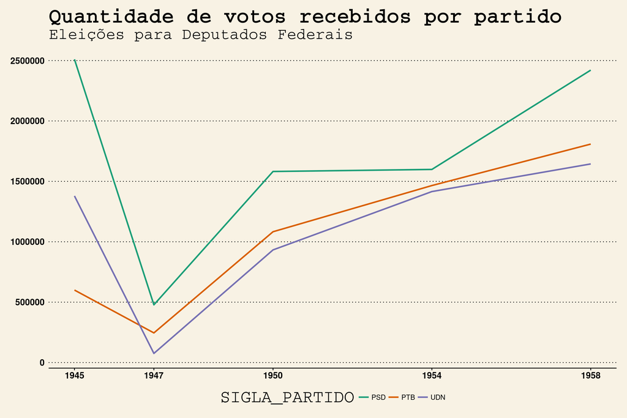

No que diz respeito aos votos recebidos pelos principais partidos do período, destaca-se o crescimento do PTB a partir de 1947, inclusive ultrapassando a UDN e mantendo um crescimento aparentemente constante.

## Qual foi o desempenho do PCB em relação aos demais partidos (porcentagem total por UF)

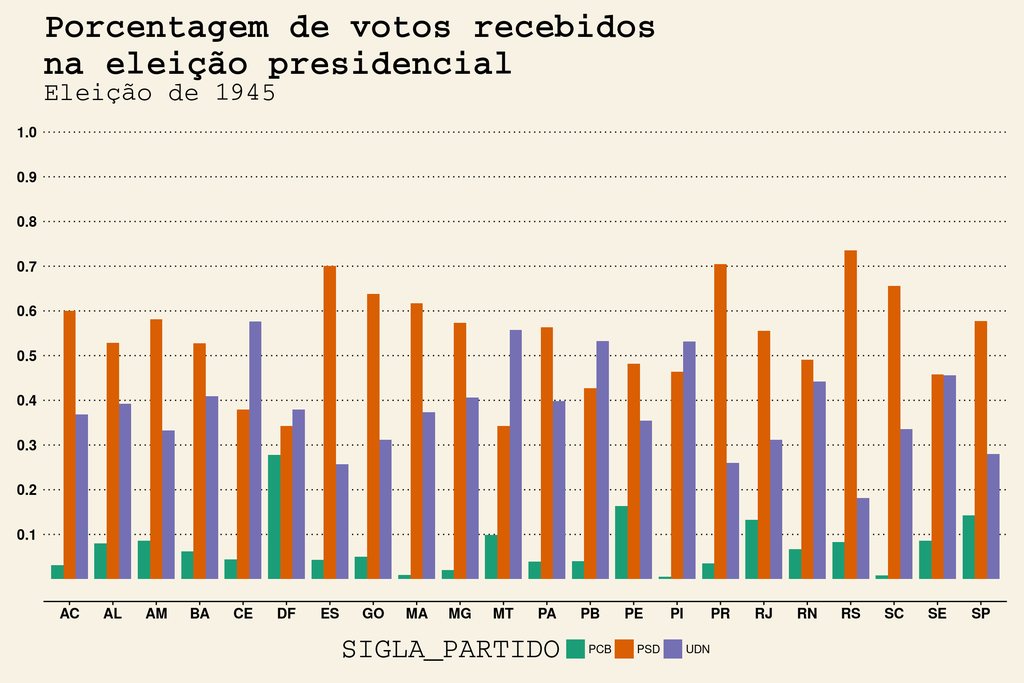

Podemos perceber que PCB teve grande destaque no DF, PE e SP, por exemplo. Seria interessante saber qual o principal eleitorado do PCB.

## Como os votos se distribuem entre os candidados à presidencia (1945)

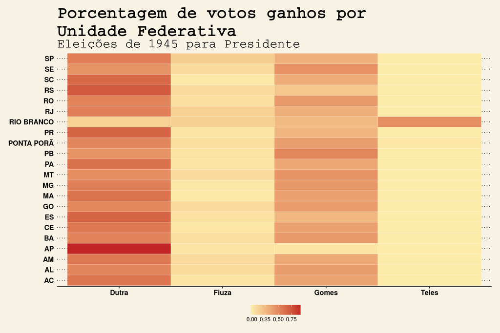

Neste gráico, também conhecido como “heatmap”, podemos notar a concentração de votos por UF. Podemos perceber que a porcentagem de votos atribuidos à Dutra se distribui ao longo de todas as unidades de análise. O mesmo também pode ser verificado para Gomes, porém a porcentagem de votos atribuidos a ele é menor do que o candidato do PSD.

No que diz respeito ao candidato do PCB, podemos perceber que em muitos locais ele recebeu menos de 25% do total. Por fim, Teles surpreende ao receber uma quantidade superior de votos no Território de Rio Branco.

## Alguns estudos de caso

Recebemos dados de alistamento do Piaui e do Pará, portanto, podemos explorar estes dados.

### Piaui

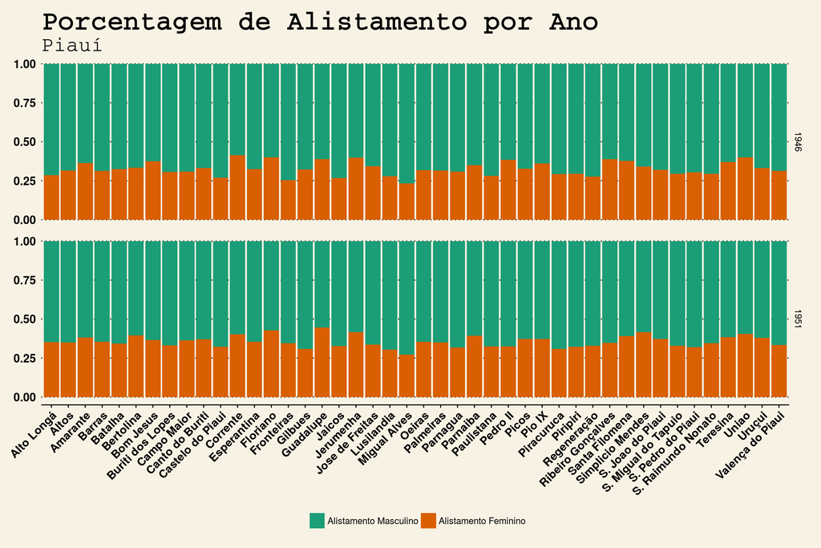

Com este dado é possível percebermos que o alistamento cresceu de um pleito para o outro, podemos inclusive ver qual foi o crescimento percentual entre os anos

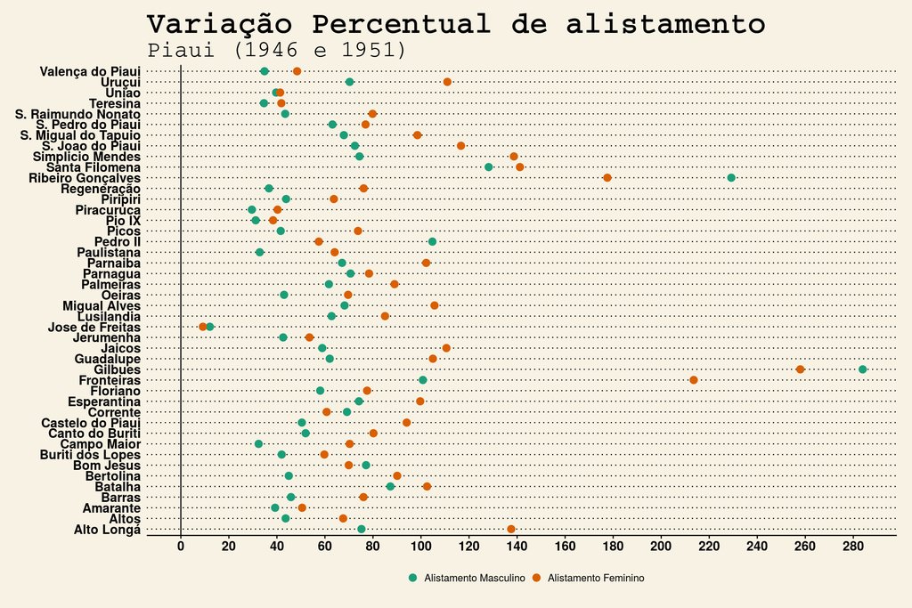

É interessante notar, que em alguns municipios houve um crescimento percentual de alistamento feminino maior que o aumento percentual de alistamento masculino.

Uma pergunta interessante a partir desta análise é verificar que já que o alistamento teve um crescimento entre 1946 e 1951, como se deu o comparecimento e a quantidade de eleitores aptos nas eleições entre estes intervalos?

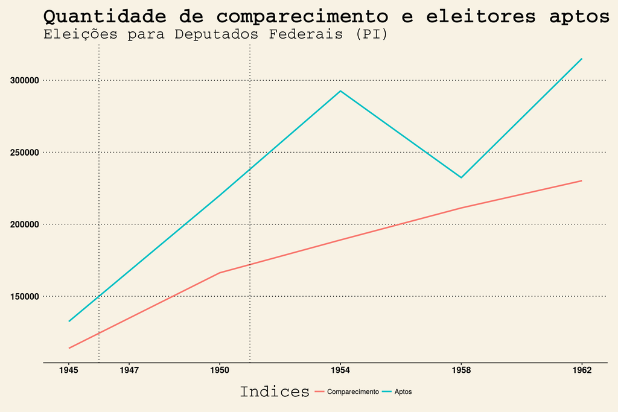

### Pará

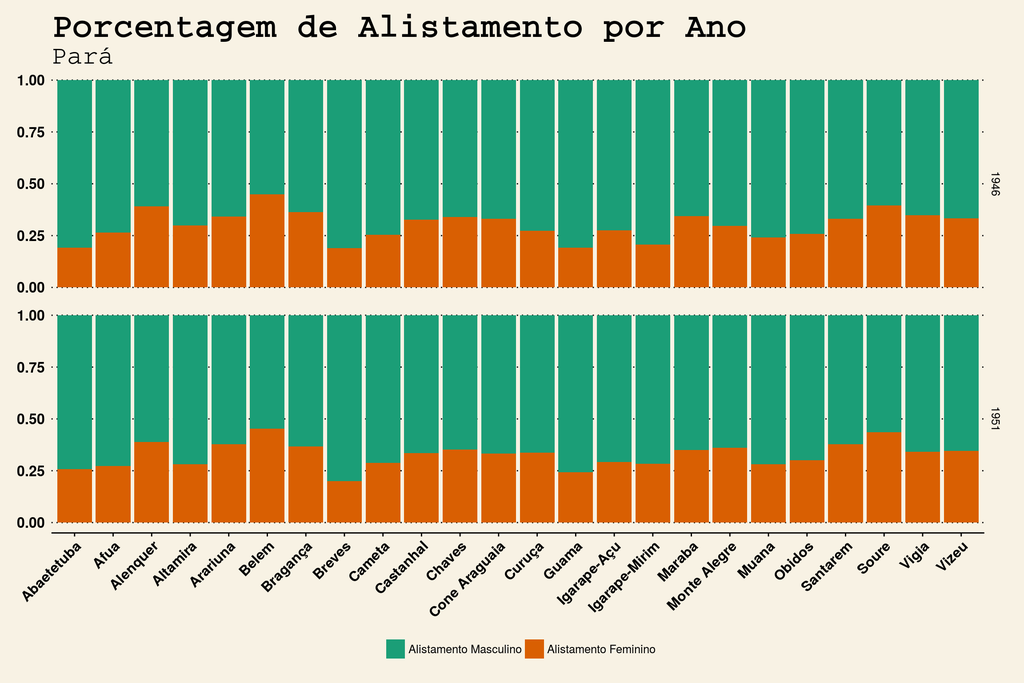

Realizando as mesmas operações…

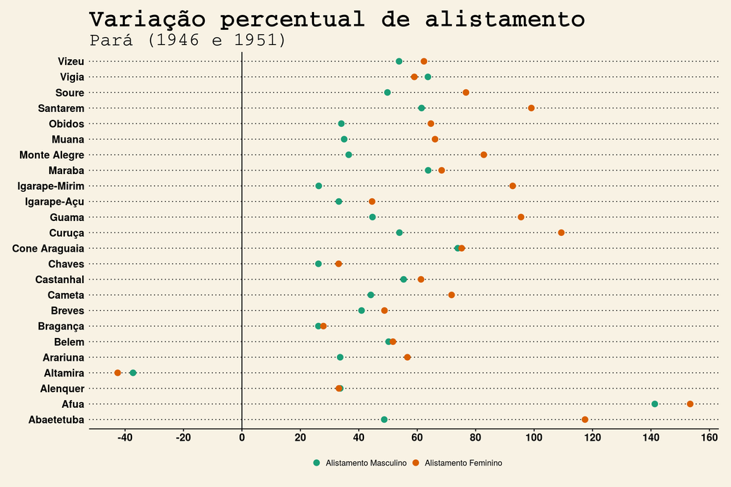

No caso do Pará vemos uma situação um pouco diferente do Piaui, inclusive de municipios cujo a variação percentual de 1946 para 1951 foi negativa.

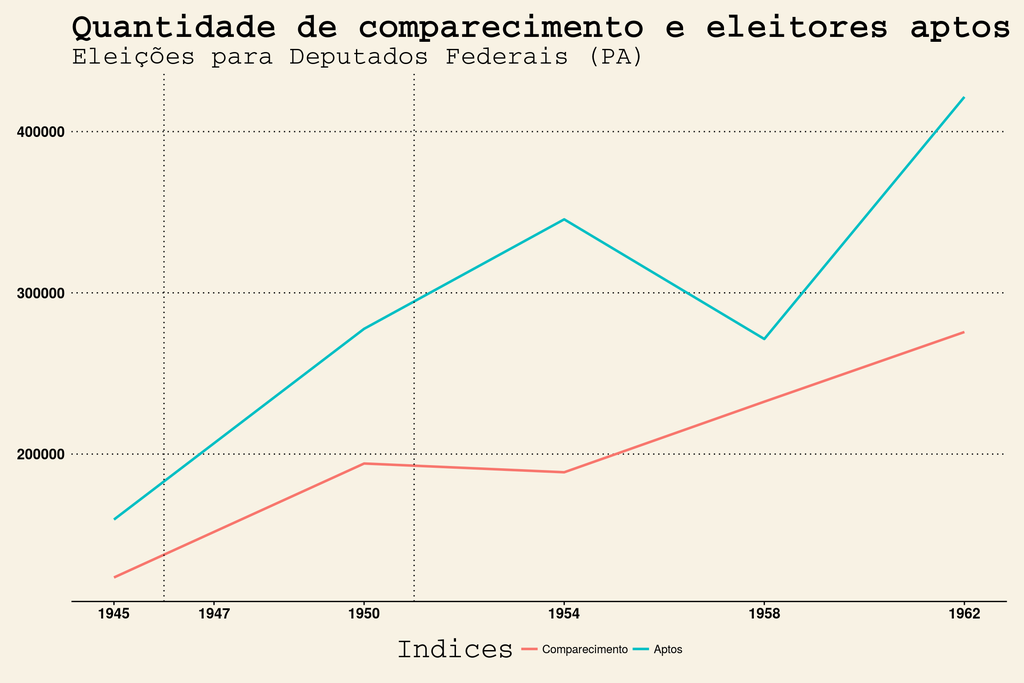

Por fim, utilizando os dados do Pará decidi georeferenciar os votos por municipio para verificar se quanto mais próximo do centro da cidade maior a atribuição de votos a um certo candidato. Ainda não completei esta tarefa, mas cheguei até o exemplo abaixo:

[interactive chart not shown]